# Balance Assessment and Survival Analysis | Tz/Dz/Az vs Tamsulosin

Jacob Simmering, PhD https://jacobsimmering.com (University of Iowa)https://uiowa.edu  
2022-05-09

```r
library("Rcpp", lib.loc = "~/R/x86_64-pc-linux-gnu-library/4.0/")
library(tidyverse)
library(gtsummary)
library(survival)
library(effectsize)
library(patchwork)
```

This file was compiled on 2022-05-09 14:48:08 by `jsimmeri` on argon-lc-f14-25.hpc.

The script `analysis_functions.R` provides:

1. some functions for summarizing the cohort and building tables that are shared across scripts
2. code to load the entire collection out outcomes data (which it returns as `model_data` to the workspace)
3. sets `root_dir` according to the location where the script is being run to handle different syntax for referring to network drives in MacOS and CentOS

```r
source("~/projects/pd-preprint/analysis/analysis_functions.R")
```

## Data Load

### Unadjusted Data

The tibble `model_data` is loaded by `analysis_functions` from /Shared/lss_jsimmeri_backup/data/tz-5ari-final. `model_data` contains data on all users of the three drugs. We want to reduce that here to just Tz/Dz/Az and tamsulosin.

```r
model_data <- model_data %>%
  filter(drug %in% c("tamsulosin", "tz/dz/az")) %>%
  mutate(treatment = drug == "tz/dz/az")
```

### Matches

We also want to load our matching results:

```r
matches <- read_rds(glue::glue("{root_dir}/matches/tz_tam.rds"))
```

And using the matches, build matched versions of the tamsulosin versus 5ARI model data:

```r
matched_model_data <- model_data %>%
  select(-treatment) %>%
  inner_join(matches,
    by = "enrolid")
```

## Balance and Cohort Description

### Before Matching

```r
describe_cohort(model_data)
```

[output not shown]

1Cohen's D  
2CI = Confidence Interval

### After Matching

```r
describe_cohort(matched_model_data)
```

| Group | Characteristic | tamsulosin, N = 119,944 | tz/dz/az, N = 119,944 | Difference1 | 95% CI12 |
| --- | --- | --- | --- | --- | --- |
| Age and Medication Start Time | Age at Index Date | 62 (55, 70) | 62 (55, 70) | 0.015 | 0.007, 0.023 |
|  | Medication Index Date | 2,009.0 (2,006.0, 2,012.0) | 2,009.0 (2,006.0, 2,012.0) | 0.011 | 0.003, 0.019 |
| Duration of Enrollment Time | Lookback Time (Years) | 3.19 (1.88, 5.50) | 2.94 (1.76, 5.30) | 0.061 | 0.052, 0.069 |
|  | Follow Up Time (Years) | 2.07 (0.92, 4.29) | 2.05 (0.93, 4.29) | -0.001 | -0.009, 0.007 |
| Rates of Inpatient and Outpatient Encounters | Inpatient Events Per Year | 0.00 (0.00, 0.14) | 0.00 (0.00, 0.13) | 0.005 | -0.003, 0.013 |
|  | Outpatient Events Per Year | 9 (5, 16) | 9 (5, 16) | 0.008 | 0.000, 0.016 |
|  | Mean Number of DX Codes Per Outpatient Event | 1.39 (1.19, 1.87) | 1.38 (1.19, 1.86) | 0.006 | -0.002, 0.014 |
|  | Outpatient DX Code Incidence Per Year | 0.04 (0.02, 0.07) | 0.04 (0.02, 0.07) | 0.010 | 0.002, 0.018 |
|  | mean_ndx_out_rate | 14 (7, 25) | 14 (7, 25) | 0.010 | 0.002, 0.018 |
| Elixhauser/AHRQ Comorbidity Flags | Alcohol Abuse | 2,684 (2.2%) | 2,599 (2.2%) | 0.005 | -0.003, 0.013 |
|  | Anemia | 16,334 (13.6%) | 16,209 (13.5%) | 0.003 | -0.005, 0.011 |
|  | Blood Loss | 1,494 (1.2%) | 1,456 (1.2%) | 0.003 | -0.005, 0.011 |
|  | Heart Failure | 9,925 (8.3%) | 9,705 (8.1%) | 0.007 | -0.001, 0.015 |
|  | Coagulopathy | 3,549 (3.0%) | 3,506 (2.9%) | 0.002 | -0.006, 0.010 |
|  | Depression | 8,731 (7.3%) | 8,660 (7.2%) | 0.002 | -0.006, 0.010 |
|  | Diabetes Without Complications | 34,932 (29.1%) | 34,735 (29.0%) | 0.004 | -0.004, 0.012 |
|  | Diabetes With Complications | 13,786 (11.5%) | 13,616 (11.4%) | 0.004 | -0.004, 0.012 |
|  | Drug Abuse | 1,300 (1.1%) | 1,299 (1.1%) | 0.000 | -0.008, 0.008 |
|  | Fluid or Electrolyte Disorders | 13,302 (11.1%) | 13,181 (11.0%) | 0.003 | -0.005, 0.011 |
|  | HIV | 493 (0.4%) | 467 (0.4%) | 0.003 | -0.005, 0.011 |
|  | HTN Without Complications | 82,991 (69.2%) | 82,654 (68.9%) | 0.006 | -0.002, 0.014 |
|  | HTN With Complications | 19,857 (16.6%) | 19,442 (16.2%) | 0.009 | 0.001, 0.017 |
|  | Hypothyroidism | 9,647 (8.0%) | 9,449 (7.9%) | 0.006 | -0.002, 0.014 |
|  | Liver Disease | 4,807 (4.0%) | 4,737 (3.9%) | 0.003 | -0.005, 0.011 |
|  | Lymphoma | 1,296 (1.1%) | 1,266 (1.1%) | 0.002 | -0.006, 0.010 |
|  | Metastatic Cancer | 1,542 (1.3%) | 1,514 (1.3%) | 0.002 | -0.006, 0.010 |
|  | Other Neurologic Disorders | 7,305 (6.1%) | 7,159 (6.0%) | 0.005 | -0.003, 0.013 |
|  | Obesity | 11,270 (9.4%) | 11,260 (9.4%) | 0.000 | -0.008, 0.008 |
|  | Paralysis | 2,013 (1.7%) | 1,985 (1.7%) | 0.002 | -0.006, 0.010 |
|  | Pulmonary Hypertension | 2,480 (2.1%) | 2,386 (2.0%) | 0.006 | -0.002, 0.014 |
|  | Psychoses | 6,816 (5.7%) | 6,637 (5.5%) | 0.006 | -0.002, 0.014 |
|  | Peptic Ulcer Disease | 290 (0.2%) | 290 (0.2%) | 0.000 | -0.008, 0.008 |
|  | COPD | 23,561 (19.6%) | 23,283 (19.4%) | 0.006 | -0.002, 0.014 |
|  | Peripheral Vascular Disease | 14,877 (12.4%) | 14,648 (12.2%) | 0.006 | -0.002, 0.014 |
|  | Renal Failure | 11,382 (9.5%) | 11,288 (9.4%) | 0.003 | -0.005, 0.011 |
|  | Rheumatoid Arthritis | 4,615 (3.8%) | 4,589 (3.8%) | 0.001 | -0.007, 0.009 |
|  | Solid Tumor | 13,662 (11.4%) | 13,507 (11.3%) | 0.004 | -0.004, 0.012 |
|  | Valvular Disease | 13,851 (11.5%) | 13,586 (11.3%) | 0.007 | -0.001, 0.015 |
|  | Weight Loss | 3,380 (2.8%) | 3,293 (2.7%) | 0.004 | -0.004, 0.012 |
| Hypotension | Orthostatic Hypotension | 957 (0.8%) | 893 (0.7%) | 0.006 | -0.002, 0.014 |
|  | Other Hypotension | 2,160 (1.8%) | 2,110 (1.8%) | 0.003 | -0.005, 0.011 |
| Prostate Specific Antigen | PSA Measurement Taken | 69,252 (57.7%) | 68,586 (57.2%) | 0.011 | 0.003, 0.019 |
|  | Diagnosis of Abnormal PSA | 14,040 (11.7%) | 13,746 (11.5%) | 0.008 | 0.000, 0.016 |
| Bladder Function and Urinary Flow | Slow Urinary Stream Diagnosis | 3,061 (2.6%) | 2,891 (2.4%) | 0.009 | 0.001, 0.017 |
|  | Uroflow Study Performed | 7,682 (6.4%) | 7,428 (6.2%) | 0.009 | 0.001, 0.017 |
|  | Cystometrogram Performed | 910 (0.8%) | 886 (0.7%) | 0.002 | -0.006, 0.010 |
|  | Diagnosis of BPH | 41,863 (34.9%) | 41,127 (34.3%) | 0.013 | 0.005, 0.021 |
| Other Comorbidities | Diagnosis of Anxiety | 7,737 (6.5%) | 7,628 (6.4%) | 0.004 | -0.004, 0.012 |
|  | Diagnosis of Erectile Dysfunction | 11,200 (9.3%) | 10,965 (9.1%) | 0.007 | -0.001, 0.015 |

1Cohen's D  
2CI = Confidence Interval

## Propensity Score Overlap

We can also visually inspect the estimated propensity scores for overlap:

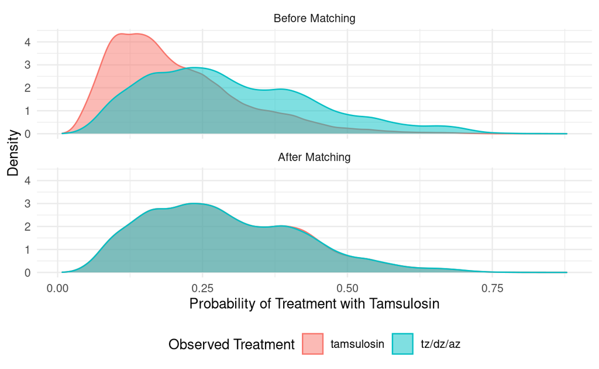

```r
ps <- read_rds(glue::glue("{root_dir}/matching_candidates/tz_tam.rds"))
bind_rows(
  model_data %>%
    inner_join(ps, by = "enrolid") %>%
    mutate(type = "Before Matching"),
  matched_model_data %>%
    inner_join(ps, by = "enrolid") %>%
    mutate(type = "After Matching")
  ) %>%
  mutate(type = forcats::fct_rev(type)) %>%
  ggplot(aes(x = ptx, fill = drug, color = drug)) +
  geom_density(alpha = 0.5) +
  labs(x = "Probability of Treatment with Tamsulosin",
       y = "Density",
       color = "Observed Treatment",
       fill = "Observed Treatment") +
  theme_minimal() +
  theme(legend.position = "bottom") +
  facet_wrap(~ type, nrow = 2)
```

## Survival Analysis

### Before Matching

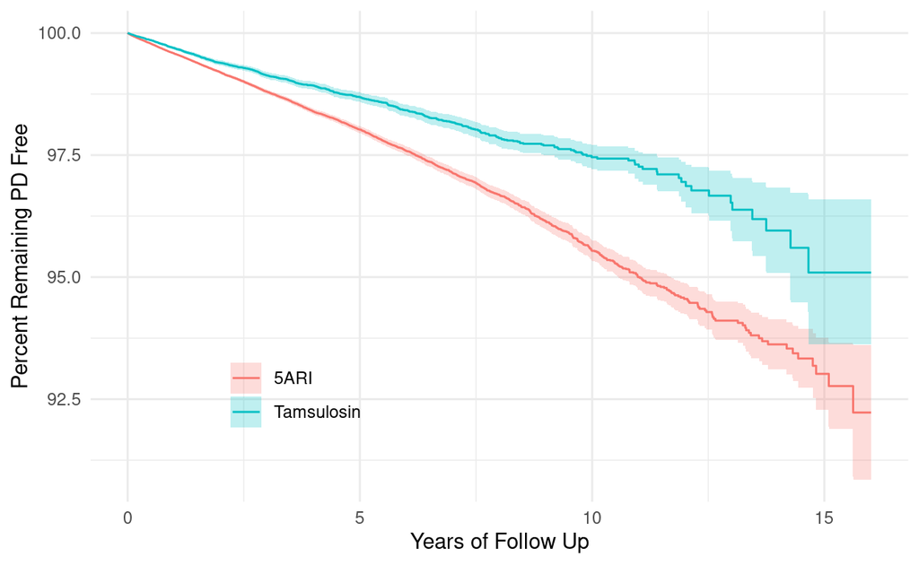

```r
survfit(Surv(survival_time, develops_pd) ~ treatment,
        data = model_data) %>%
  broom::tidy() %>%
  mutate(treatment = ifelse(strata == "treatment=TRUE",
    "Tamsulosin", "5ARI")) %>%
  ggplot(
    aes(
      x = time / 365,
      y = 100 * estimate,
      ymin = 100 * conf.low,
      ymax = 100 * conf.high
    )
  ) +
  geom_step(aes(color = treatment)) +
  geom_ribbon(aes(fill = treatment), alpha = 0.25) +
  theme_minimal() +
  labs(x = "Years of Follow Up", y = "Percent Remaining PD Free",
       color = "", fill = "") +
  theme(legend.position = c(0.25, 0.25))
```

A finding that is statistically significant using the log rank test:

```r
survdiff(Surv(survival_time, develops_pd) ~ treatment,
         data = model_data)
```

```
Call:
survdiff(formula = Surv(survival_time, develops_pd) ~ treatment,
    data = model_data)

                     N Observed Expected (O-E)^2/E (O-E)^2/V
treatment=FALSE 429741     4867     4476      34.2       143
treatment=TRUE  124905     1022     1413     108.3       143

 Chisq= 143  on 1 degrees of freedom, p= <2e-16
```

```r
raw_cox <- coxph(Surv(survival_time, develops_pd) ~ as.numeric(treatment),
                 data = model_data,
                 robust = TRUE)
tbl_regression(raw_cox, exponentiate = TRUE)
```

| **Characteristic** | **HR**<sup>1</sup> | **95% CI**<sup>1</sup> | **p-value** |
| --- | --- | --- | --- |
| as.numeric(treatment) | 0.66 | 0.62, 0.71 | <0.001 |

<sup>*1*</sup> HR = Hazard Ratio, CI = Confidence Interval

However, this estimate is not trustworthy as we know the groups could be better balanced.

### With Propensity Score Matching

Further adjustment yields similar results.

We observe the following overall incidence:

```r
matched_model_data %>%
  group_by(drug) %>%
  summarize(
    cases = sum(develops_pd),
    time = sum(survival_time / 365),
    incidence = cases / time * 10000
  ) %>%
  knitr::kable()
```

| drug | cases | time | incidence |
| --- | --- | --- | --- |
| tamsulosin | 1391 | 358504.4 | 38.80008 |
| tz/dz/az | 991 | 359705.2 | 27.55034 |

With a Kaplan Meier curve:

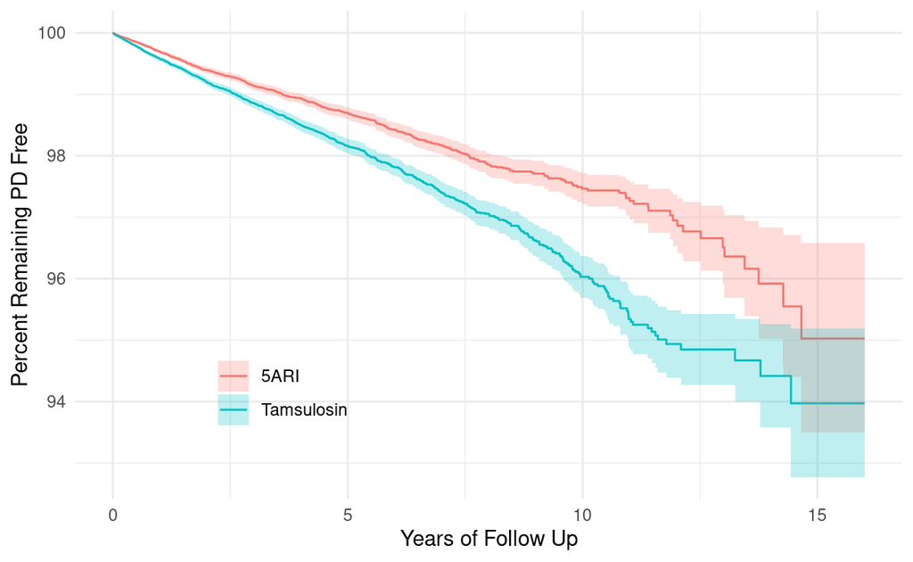

```r
survfit(Surv(survival_time, develops_pd) ~ drug,
        data = matched_model_data) %>%
  broom::tidy() %>%
  mutate(treatment = ifelse(strata == "drug=tamsulosin",
    "Tamsulosin", "5ARI")) %>%
  ggplot(
    aes(
      x = time / 365,
      y = 100 * estimate,
      ymin = 100 * conf.low,
      ymax = 100 * conf.high
    )
  ) +
  geom_step(aes(color = treatment)) +
  geom_ribbon(aes(fill = treatment), alpha = 0.25) +
  theme_minimal() +
  labs(x = "Years of Follow Up", y = "Percent Remaining PD Free",
       color = "", fill = "") +
  theme(legend.position = c(0.25, 0.25))
```

The population size at risk by year is given in the table below:

```r
survfit(Surv(survival_time, develops_pd) ~ drug,
        data = matched_model_data) %>%
  broom::tidy() %>%
  select(strata, time,, n.risk) %>%
  complete(strata, time = 0:(16*365)) %>%
  fill(n.risk, .direction = "down") %>%
  mutate(drug = ifelse(strata == "drug=tamsulosin", "Tamsulosin", "TZ/DZ/AZ")) %>%
  select(time, drug, n.risk) %>%
  filter(time %in% c(1:16 * 365)) %>%
  mutate(year = round(time / 365)) %>%
  spread(drug, n.risk) %>%
  knitr::kable()
```

| time | year | Tamsulosin | TZ/DZ/AZ |
| --- | --- | --- | --- |
| 365 | 1 | 86903 | 87067 |
| 730 | 2 | 60751 | 60535 |
| 1095 | 3 | 44291 | 44272 |
| 1460 | 4 | 32414 | 32461 |
| 1825 | 5 | 23443 | 23524 |
| 2190 | 6 | 16894 | 16944 |
| 2555 | 7 | 12166 | 12186 |
| 2920 | 8 | 8306 | 8332 |
| 3285 | 9 | 5535 | 5554 |
| 3650 | 10 | 3484 | 3568 |
| 4015 | 11 | 2124 | 2146 |
| 4380 | 12 | 1133 | 1121 |
| 4745 | 13 | 629 | 646 |
| 5110 | 14 | 304 | 317 |
| 5475 | 15 | 121 | 117 |
| 5840 | 16 | 2 | 3 |

A log rank test confirms that the curves remain different.

```r
survdiff(Surv(survival_time, develops_pd) ~ treatment,
         data = matched_model_data)
```

```
Call:
survdiff(formula = Surv(survival_time, develops_pd) ~ treatment,
    data = matched_model_data)

                 N Observed Expected (O-E)^2/E (O-E)^2/V
treatment=0 119944     1391     1189      34.3      68.5
treatment=1 119944      991     1193      34.2      68.5

 Chisq= 68.5  on 1 degrees of freedom, p= <2e-16
```

Survival times

```r
tbl_survfit(
  survfit(
    Surv(survival_time, develops_pd) ~ drug, data = matched_model_data
  ),
  probs = seq(0.5, 2, by = 0.5) / 100
)
```

| **Characteristic** | **0.5% Percentile** | **1.0% Percentile** | **1.5% Percentile** | **2.0% Percentile** |
| --- | --- | --- | --- | --- |
| drug |  |  |  |  |
| tamsulosin | 442 (412, 496) | 958 (890, 1,015) | 1,463 (1,380, 1,584) | 1,996 (1,891, 2,156) |
| tz/dz/az | 595 (547, 651) | 1,317 (1,237, 1,481) | 2,100 (1,968, 2,264) | 2,768 (2,578, 3,030) |

We fit a Cox regression model to estimate the differences in hazard:

```r
full_cox <- coxph(Surv(survival_time, develops_pd) ~ as.numeric(treatment),
                       data = matched_model_data,
                       robust = TRUE)
tbl_regression(full_cox, exponentiate = TRUE)
```

| **Characteristic** | **HR**<sup>1</sup> | **95% CI**<sup>1</sup> | **p-value** |
| --- | --- | --- | --- |
| as.numeric(treatment) | 0.71 | 0.65, 0.77 | <0.001 |

<sup>*1*</sup> HR = Hazard Ratio, CI = Confidence Interval

## Fit Summaries

```r
tbl_merge(
  tbls = list(
    tbl_regression(raw_cox, exponentiate = TRUE),
    tbl_regression(full_cox, exponentiate = TRUE)
  ),
  tab_spanner = c("Unadjusted", "Propensity Score Matched")
) %>%
  as_flex_table()
```

| Characteristic | Unadjusted HR1 | Unadjusted 95% CI1 | Unadjusted p-value | Propensity Score Matched HR1 | Propensity Score Matched 95% CI1 | Propensity Score Matched p-value |
| --- | --- | --- | --- | --- | --- | --- |
| as.numeric(treatment) | 0.66 | 0.62, 0.71 | <0.001 | 0.71 | 0.65, 0.77 | <0.001 |

1HR = Hazard Ratio, CI = Confidence Interval

## Diagnostics

```r
scf_residuals <- cox.zph(full_cox)
scf_residuals
```

```
                      chisq df    p
as.numeric(treatment)  1.98  1 0.16
GLOBAL                 1.98  1 0.16
```

```r
with(scf_residuals, cor.test(x, y))
```

```
    Pearson's product-moment correlation

data:  x and y
t = -1.4089, df = 2380, p-value = 0.159
alternative hypothesis: true correlation is not equal to 0
95 percent confidence interval:
 -0.06894934  0.01130818
sample estimates:
       cor
-0.0288671
```

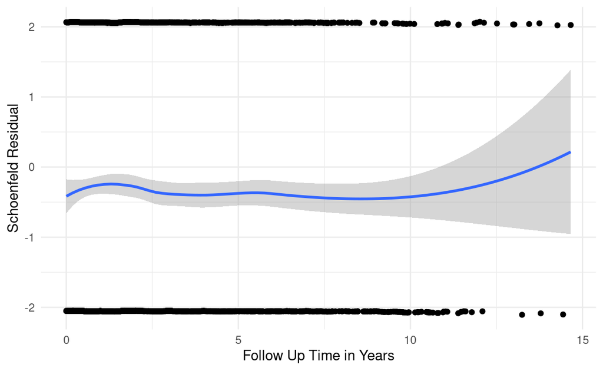

```r
tibble(
  x = scf_residuals$time,
  y = scf_residuals$y
) %>%
  ggplot(aes(x = x / 365, y = y)) +
  geom_point() +
  geom_smooth(method = "loess") +
  labs(x = "Follow Up Time in Years", y = "Schoenfeld Residual") +
  theme_minimal()
```